# Homework 7

### Homework 7

Nathan Deinlein

```python
from bs4 import BeautifulSoup
import requests
import nltk
import csv
import pandas as pd
from nltk.corpus import stopwords
from nltk.tokenize import word_tokenize, sent_tokenize
from textblob import TextBlob
from wordcloud import WordCloud
```

### Cluster the reviews that you collected in homework 5, by doing the following:

#### 1. In Python, select any one of the clustering methods covered in this course. Run it over the collection of reviews, and show at least two different ways of clustering the reviews, e.g., changing k in k-Means clustering or changing where you “cut” in Agnes or Diana.

```python
#import reviews
file = open("C:/Users/nedei/Documents/School/NLP/test.csv","r")
csv_reader = csv.reader(file)
urls = []
for row in csv_reader:
    urls.extend(row)
reviews = []
tags = []
for x in urls:
    result = requests.get(x)
    doc = BeautifulSoup(result.text, "html.parser")
    tag = doc.title
    tag = tag.text.strip()
    review = doc.find('div',{'class':'text show-more__control'})
    review = review.text.strip()
    reviews.append(review)
    tags.append(tag)
```

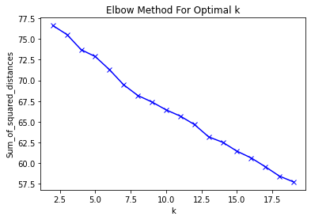

```python
from sklearn.feature_extraction.text import TfidfVectorizer
vectorizer = TfidfVectorizer(stop_words={'english'})
X = vectorizer.fit_transform(reviews)

import matplotlib.pyplot as plt
from sklearn.cluster import KMeans
Sum_of_squared_distances = []
K = range(2,20)
for k in K:
   km = KMeans(n_clusters=k, max_iter=200, n_init=10)
   km = km.fit(X)
   Sum_of_squared_distances.append(km.inertia_)
plt.plot(K, Sum_of_squared_distances, 'bx-')
plt.xlabel('k')
plt.ylabel('Sum_of_squared_distances')
plt.title('Elbow Method For Optimal k')
plt.show()
```

```python
true_k = 11
model = KMeans(n_clusters=true_k, init='k-means++', max_iter=200, n_init=10)
model.fit(X)
labels=model.labels_
artcluster=pd.DataFrame(list(zip(tags,reviews,labels)),columns=['Tag','Review','cluster'])
print(artcluster.sort_values(by=['cluster']))
```

```
                                             Tag  \
97    imdb-19548's Review of Citizen Kane - IMDb
12      Prismark10's Review of Casablanca - IMDb
16       gavin6942's Review of Casablanca - IMDb
15   lee_eisenberg's Review of Casablanca - IMDb
14  classicsoncall's Review of Casablanca - IMDb
..                                           ...
67  FilmCriticLalitRao's Review of Psycho - IMDb
72    Lebrocq17's Review of Seven Samurai - IMDb
91    bkoganbing's Review of Citizen Kane - IMDb
99     CarmaChan's Review of Citizen Kane - IMDb
35    adamjohns-42575's Review of Top Hat - IMDb

                                               Review  cluster
97  Given the legendary status of this film I was ...        0
12  Writer and story consultant Robert McKee regar...        1
16  In Casablanca, Morocco, during World War II, t...        1
15  Overall, "Casablanca" went a little overboard ...        1
14  "Casablanca" has been my favorite movie for th...        1
..                                                ...      ...
67  After having heard all the noise surrounding t...        9
72  I gave this film a 1 out of 10 simply to try a...        9
91  The problem with writing about a film like Cit...        9
99  For the life of me, I have tried hard to under...        9
35  I think I might have been expecting too much f...       10

[100 rows x 3 columns]
```

```
Cluster: 0
Titles
 imdb-19548's Review of Citizen Kane - IMDb
```

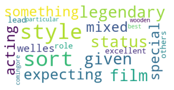

```
Cluster: 1
Titles
            Tweekums's Review of Casablanca - IMDb
           ma-cortes's Review of Casablanca - IMDb
       moonspinner55's Review of Casablanca - IMDb
          bkoganbing's Review of Casablanca - IMDb
         SnoopyStyle's Review of Casablanca - IMDb
 Horst_In_Translation's Review of Casablanca - ...
          Prismark10's Review of Casablanca - IMDb
    claudio_carvalho's Review of Casablanca - IMDb
      classicsoncall's Review of Casablanca - IMDb
       lee_eisenberg's Review of Casablanca - IMDb
           gavin6942's Review of Casablanca - IMDb
       jboothmillard's Review of Casablanca - IMDb
          rmax304823's Review of Casablanca - IMDb
```

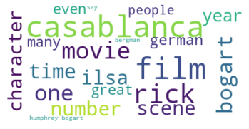

```
Cluster: 2
Titles
   TheLittleSongbird's Review of Casablanca - IMDb
        Kirpianuscus's Review of Casablanca - IMDb
 tracywinters-44332's Review of It's a Wonderfu...
  Norm-30's Review of It's a Wonderful Life - IMDb
   Qanqor's Review of It's a Wonderful Life - IMDb
 AleksandrBelenko's Review of It's a Wonderful ...
 llihilloh's Review of It's a Wonderful Life - ...
 CineCritic2517's Review of It's a Wonderful Li...
 winner55's Review of It's a Wonderful Life - IMDb
 TheLittleSongbird's Review of It's a Wonderful...
 johnno-17's Review of It's a Wonderful Life - ...
 Jack the Ripper1888's Review of Young Frankens...
      igiana's Review of Young Frankenstein - IMDb
  leplatypus's Review of The Great Dictator - IMDb
   arwkoppen's Review of The Great Dictator - IMDb
  tom-durham's Review of The Great Dictator - IMDb
       TheLittleSongbird's Review of Psycho - IMDb
          jonasatmosfera's Review of Psycho - IMDb
       phoobeyfax's Review of Seven Samurai - IMDb
 TheLittleSongbird's Review of Seven Samurai - ...
 TheLittleSongbird's Review of Arsenic and Old ...
 TheLittleSongbird's Review of Citizen Kane - IMDb
       SnoopyStyle's Review of Citizen Kane - IMDb
 alirezazamani-73059's Review of Citizen Kane -...
```

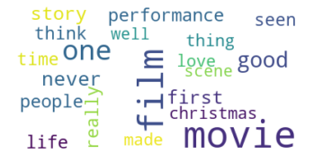

```
Cluster: 3
Titles
 ma-cortes's Review of Arsenic and Old Lace - IMDb
 classicsoncall's Review of Arsenic and Old Lac...
 nogodnomasters's Review of Arsenic and Old Lac...
 claudio_carvalho's Review of Arsenic and Old L...
 Prismark10's Review of Arsenic and Old Lace - ...
 mark.waltz's Review of Arsenic and Old Lace - ...
 SnoopyStyle's Review of Arsenic and Old Lace -...
 bkoganbing's Review of Arsenic and Old Lace - ...
 MartinHafer's Review of Arsenic and Old Lace -...
```

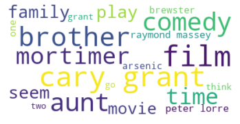

```
Cluster: 4
Titles
 MartinHafer's Review of The Great Dictator - IMDb
 TheLittleSongbird's Review of The Great Dictat...
  bkoganbing's Review of The Great Dictator - IMDb
 Leofwine_draca's Review of The Great Dictator ...
 Michael_Elliott's Review of The Great Dictator...
       abenr's Review of The Great Dictator - IMDb
 followerofali's Review of The Great Dictator -...
```

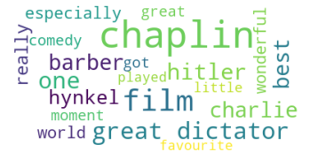

```
Cluster: 5
Titles
       MartinHafer's Review of Top Hat - IMDb
 TheLittleSongbird's Review of Top Hat - IMDb
        bkoganbing's Review of Top Hat - IMDb
       SnoopyStyle's Review of Top Hat - IMDb
          Hitchcoc's Review of Top Hat - IMDb
   ccthemovieman-1's Review of Top Hat - IMDb
     moonspinner55's Review of Top Hat - IMDb
      Celeste_1977's Review of Top Hat - IMDb
 studios-341-70152's Review of Top Hat - IMDb
```

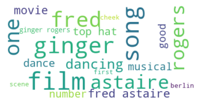

```
Cluster: 6
Titles
         MartinHafer's Review of Casablanca - IMDb
     Michael_Elliott's Review of Casablanca - IMDb
            Hitchcoc's Review of Casablanca - IMDb
          mark.waltz's Review of Casablanca - IMDb
     ccthemovieman-1's Review of Casablanca - IMDb
 MartinHafer's Review of It's a Wonderful Life ...
 thestevemacbeth's Review of Young Frankenstein...
            Irishchatter's Review of Psycho - IMDb
            Movieman-133's Review of Psycho - IMDb
          noahmed's Review of Seven Samurai - IMDb
    caesarmoridon's Review of Seven Samurai - IMDb
         Hitchcoc's Review of Seven Samurai - IMDb
      SnoopyStyle's Review of Seven Samurai - IMDb
   Leofwine_draca's Review of Seven Samurai - IMDb
      MartinHafer's Review of Seven Samurai - IMDb
```

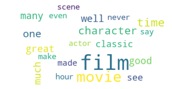

```
Cluster: 7
Titles
 MartinHafer's Review of Young Frankenstein - IMDb
 TheLittleSongbird's Review of Young Frankenste...
  bkoganbing's Review of Young Frankenstein - IMDb
 Leofwine_draca's Review of Young Frankenstein ...
 SnoopyStyle's Review of Young Frankenstein - IMDb
    Hitchcoc's Review of Young Frankenstein - IMDb
```

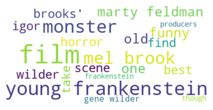

```
Cluster: 8
Titles
     bkoganbing's Review of Psycho - IMDb
 Leofwine_draca's Review of Psycho - IMDb
    SnoopyStyle's Review of Psycho - IMDb
       Hitchcoc's Review of Psycho - IMDb
```

[figure not shown]

```
Cluster: 9
Titles
   kenandraf's Review of Young Frankenstein - IMDb
 Kdosda_Hegen's Review of The Great Dictator - ...
      FilmCriticLalitRao's Review of Psycho - IMDb
         artkozak's Review of Seven Samurai - IMDb
        Lebrocq17's Review of Seven Samurai - IMDb
        bkoganbing's Review of Citizen Kane - IMDb
    Leofwine_draca's Review of Citizen Kane - IMDb
          Hitchcoc's Review of Citizen Kane - IMDb
           kosmasp's Review of Citizen Kane - IMDb
      heisenberg12's Review of Citizen Kane - IMDb
         CarmaChan's Review of Citizen Kane - IMDb
```

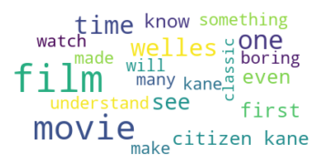

```
Cluster: 10
Titles
 adamjohns-42575's Review of Top Hat - IMDb
```

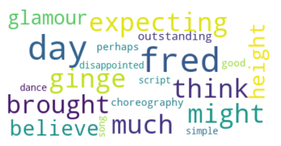

```python
result={'cluster':labels,'Tag':tags,'Review':reviews}
result=pd.DataFrame(result)
for k in range(0,true_k):
   s=result[result.cluster==k]
   text=s['Review'].str.cat(sep=' ')
   text=text.lower()
   text=' '.join([word for word in text.split()])
   wordcloud = WordCloud(max_font_size=50, max_words=20, background_color="white").generate(text)
   print('Cluster: {}'.format(k))
   print('Titles')
   titles=artcluster[artcluster.cluster==k]['Tag']
   print(titles.to_string(index=False))
   plt.figure()
   plt.imshow(wordcloud, interpolation="bilinear")
   plt.axis("off")
   plt.show()
```

```python
true_k = 4
model = KMeans(n_clusters=true_k, init='k-means++', max_iter=200, n_init=10)
model.fit(X)
labels=model.labels_
artcluster=pd.DataFrame(list(zip(tags,reviews,labels)),columns=['Tag','Review','cluster'])
print(artcluster.sort_values(by=['cluster']))
```

```
                                                  Tag  \
84  Prismark10's Review of Arsenic and Old Lace - ...
82  nogodnomasters's Review of Arsenic and Old Lac...
83  claudio_carvalho's Review of Arsenic and Old L...
85  mark.waltz's Review of Arsenic and Old Lace - ...
86  SnoopyStyle's Review of Arsenic and Old Lace -...
..                                                ...
42   bkoganbing's Review of Young Frankenstein - IMDb
43  Leofwine_draca's Review of Young Frankenstein ...
44  SnoopyStyle's Review of Young Frankenstein - IMDb
45     Hitchcoc's Review of Young Frankenstein - IMDb
46  Jack the Ripper1888's Review of Young Frankens...

                                               Review  cluster
84  Arsenic and Old Lace is a farce directed by Fr...        0
82  Cary Grant a recently married confirmed bachel...        0
83  On Halloween day, the writer and drama critic ...        0
85  If I was going to be poisoned, I couldn't thin...        0
86  Mortimer Brewster (Cary Grant) is a drama crit...        0
..                                                ...      ...
42  Mel Brooks set his comic genius to satirizing ...        3
43  YOUNG FRANKENSTEIN is a Mel Brooks horror spoo...        3
44  Dr. Frankenstein (Gene Wilder) has been living...        3
45  I can't watch the original anymore without gig...        3
46  I was hoping for a non-stop laugh fest when I ...        3

[100 rows x 3 columns]
```

```
Cluster: 0
Titles
 ma-cortes's Review of Arsenic and Old Lace - IMDb
 classicsoncall's Review of Arsenic and Old Lac...
 nogodnomasters's Review of Arsenic and Old Lac...
 claudio_carvalho's Review of Arsenic and Old L...
 Prismark10's Review of Arsenic and Old Lace - ...
 mark.waltz's Review of Arsenic and Old Lace - ...
 SnoopyStyle's Review of Arsenic and Old Lace -...
 bkoganbing's Review of Arsenic and Old Lace - ...
 TheLittleSongbird's Review of Arsenic and Old ...
 MartinHafer's Review of Arsenic and Old Lace -...
```

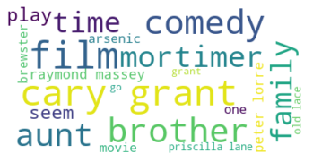

```
Cluster: 1
Titles
 igiana's Review of Young Frankenstein - IMDb
   Lebrocq17's Review of Seven Samurai - IMDb
```

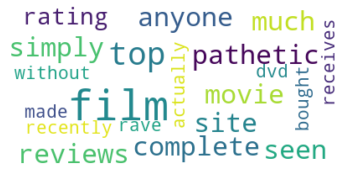

```
Cluster: 2
Titles
         MartinHafer's Review of Casablanca - IMDb
            Tweekums's Review of Casablanca - IMDb
           ma-cortes's Review of Casablanca - IMDb
       moonspinner55's Review of Casablanca - IMDb
   TheLittleSongbird's Review of Casablanca - IMDb
          bkoganbing's Review of Casablanca - IMDb
     Michael_Elliott's Review of Casablanca - IMDb
         SnoopyStyle's Review of Casablanca - IMDb
            Hitchcoc's Review of Casablanca - IMDb
        Kirpianuscus's Review of Casablanca - IMDb
 Horst_In_Translation's Review of Casablanca - ...
          mark.waltz's Review of Casablanca - IMDb
          Prismark10's Review of Casablanca - IMDb
    claudio_carvalho's Review of Casablanca - IMDb
      classicsoncall's Review of Casablanca - IMDb
       lee_eisenberg's Review of Casablanca - IMDb
           gavin6942's Review of Casablanca - IMDb
       jboothmillard's Review of Casablanca - IMDb
          rmax304823's Review of Casablanca - IMDb
     ccthemovieman-1's Review of Casablanca - IMDb
 tracywinters-44332's Review of It's a Wonderfu...
  Norm-30's Review of It's a Wonderful Life - IMDb
   Qanqor's Review of It's a Wonderful Life - IMDb
 AleksandrBelenko's Review of It's a Wonderful ...
 llihilloh's Review of It's a Wonderful Life - ...
 CineCritic2517's Review of It's a Wonderful Li...
 winner55's Review of It's a Wonderful Life - IMDb
 TheLittleSongbird's Review of It's a Wonderful...
 MartinHafer's Review of It's a Wonderful Life ...
 johnno-17's Review of It's a Wonderful Life - ...
            MartinHafer's Review of Top Hat - IMDb
      TheLittleSongbird's Review of Top Hat - IMDb
             bkoganbing's Review of Top Hat - IMDb
            SnoopyStyle's Review of Top Hat - IMDb
               Hitchcoc's Review of Top Hat - IMDb
        adamjohns-42575's Review of Top Hat - IMDb
        ccthemovieman-1's Review of Top Hat - IMDb
          moonspinner55's Review of Top Hat - IMDb
```

[output cut: 28 more lines]

```
         Hitchcoc's Review of Seven Samurai - IMDb
      SnoopyStyle's Review of Seven Samurai - IMDb
   Leofwine_draca's Review of Seven Samurai - IMDb
 TheLittleSongbird's Review of Seven Samurai - ...
      MartinHafer's Review of Seven Samurai - IMDb
 TheLittleSongbird's Review of Citizen Kane - IMDb
        bkoganbing's Review of Citizen Kane - IMDb
    Leofwine_draca's Review of Citizen Kane - IMDb
       SnoopyStyle's Review of Citizen Kane - IMDb
          Hitchcoc's Review of Citizen Kane - IMDb
           kosmasp's Review of Citizen Kane - IMDb
      heisenberg12's Review of Citizen Kane - IMDb
        imdb-19548's Review of Citizen Kane - IMDb
 alirezazamani-73059's Review of Citizen Kane -...
         CarmaChan's Review of Citizen Kane - IMDb
```

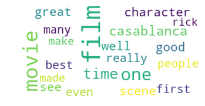

```
Cluster: 3
Titles
 MartinHafer's Review of Young Frankenstein - IMDb
 TheLittleSongbird's Review of Young Frankenste...
  bkoganbing's Review of Young Frankenstein - IMDb
 Leofwine_draca's Review of Young Frankenstein ...
 SnoopyStyle's Review of Young Frankenstein - IMDb
    Hitchcoc's Review of Young Frankenstein - IMDb
 Jack the Ripper1888's Review of Young Frankens...
```

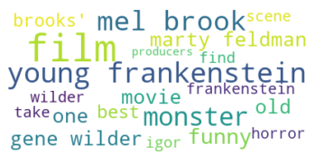

```python
result={'cluster':labels,'Tag':tags,'Review':reviews}
result=pd.DataFrame(result)
for k in range(0,true_k):
   s=result[result.cluster==k]
   text=s['Review'].str.cat(sep=' ')
   text=text.lower()
   text=' '.join([word for word in text.split()])
   wordcloud = WordCloud(max_font_size=50, max_words=20, background_color="white").generate(text)
   print('Cluster: {}'.format(k))
   print('Titles')
   titles=artcluster[artcluster.cluster==k]['Tag']
   print(titles.to_string(index=False))
   plt.figure()
   plt.imshow(wordcloud, interpolation="bilinear")
   plt.axis("off")
   plt.show()
```

#### 2. Try to write a short phrase to characterize (give a natural interpretation of) what each cluster is generally centered on semantically. Is this hard to do in some cases? If so, make note of that fact.

Looking at the first group of clustering it almost looks like it built everything out by each movie. Which is nice but it causes the whatever the largest sentiment for each movie to basically overwhelm the word chart. This makes it hard to group the movies into say good and bad. The second group of clustering gives us a little bit more. It at least groups the movies into like groups but overwhelmingly we still see positive sentiment.

#### 3. Explain which of the two clustering results from question 1 is preferable (if one of them is), and why.

Submit all of your inputs and outputs and your code for this assignment, along with a brief written explanation of your findings.

As stated above I personally like clustering two. It forces the movies into more categorical groups this allows for a more clear sentiment analysis of the group. It would probably have worked even better had I tried to classify them into a two groups